# Modelling regression trees with R’s caret package

Printing the final model and running `rpart`’s summary command both produce various statistics to help us evaluate and interpret this model.

```r
rpart.simple
```

```
## n= 4682
##
## node), split, n, deviance, yval
##       * denotes terminal node
##
##  1) root 4682 6550.3800 6.704452
##    2) computer.yes< 0.5 4101 4518.7630 6.495475
##      4) members>=2.5 2675 2095.1860 6.169479
##        8) microwave.no>=0.5 1852 1126.0140 5.944017 *
##        9) microwave.no< 0.5 823  663.1794 6.676837 *
##      5) members< 2.5 1426 1606.0200 7.107003
##       10) washer.no>=0.5 1208 1131.5870 6.929046 *
##       11) washer.no< 0.5 218  224.1929 8.093110 *
##    3) computer.yes>=0.5 581  588.3661 8.179520 *
```

```r
summary(rpart.simple)
```

```
## Call:
## rpart(formula = income ~ ., data = training, method = "anova",
##     control = rpart.control(minsplit = 20, minbucket = round(20/3),
##         cp = 0.03, maxcompete = 4, maxsurrogate = 5, usesurrogate = 2,
##         xval = 10, surrogatestyle = 0, maxdepth = 30))
##   n= 4682
##
##           CP nsplit rel error    xerror       xstd
## 1 0.22033088      0 1.0000000 1.0005080 0.02132094
## 2 0.12481058      1 0.7796691 0.7807775 0.01809380
## 3 0.04671371      2 0.6548585 0.6561443 0.01590449
## 4 0.03820242      3 0.6081448 0.6123430 0.01508921
## 5 0.03000000      4 0.5699424 0.5765729 0.01424737
##
## Variable importance
##     computer.yes      computer.no          members        washer.no
##               24               23               13                6
##       washer.yes     microwave.no    microwave.yes     satelite.yes
##                6                5                5                3
##      satelite.no       camera.yes            rooms        camera.no
##                3                3                2                2
##  dwelling.own.no dwelling.own.yes landline.working         head.age
##                1                1                1                1
##         video.no dwelling.flatlet
##                1                1
##
## Node number 1: 4682 observations,    complexity param=0.2203309
##   mean=6.704452, MSE=1.399056
##   left son=2 (4101 obs) right son=3 (581 obs)
##   Primary splits:
##       computer.yes < 0.5  to the left,  improve=0.2203309, (0 missing)
##       computer.no  < 0.5  to the right, improve=0.2179099, (0 missing)
##       washer.no    < 0.5  to the right, improve=0.2068508, (0 missing)
##       washer.yes   < 0.5  to the left,  improve=0.2047335, (0 missing)
##       microwave.no < 0.5  to the right, improve=0.1929021, (0 missing)
##   Surrogate splits:
##       computer.no  < 0.5  to the right, agree=0.996, adj=0.969, (0 split)
##       satelite.yes < 0.5  to the left,  agree=0.892, adj=0.129, (0 split)
##       satelite.no  < 0.5  to the right, agree=0.889, adj=0.108, (0 split)
##       camera.yes   < 0.5  to the left,  agree=0.889, adj=0.107, (0 split)
```

[output cut: 49 more lines]

```
##       satelite.no      < 0.5  to the right, agree=0.864, adj=0.110, (0 split)
##       microwave.yes    < 0.5  to the left,  agree=0.863, adj=0.106, (0 split)
##       microwave.no     < 0.5  to the right, agree=0.863, adj=0.106, (0 split)
##
## Node number 8: 1852 observations
##   mean=5.944017, MSE=0.6079988
##
## Node number 9: 823 observations
##   mean=6.676837, MSE=0.8058073
##
## Node number 10: 1208 observations
##   mean=6.929046, MSE=0.9367443
##
## Node number 11: 218 observations
##   mean=8.09311, MSE=1.028408
```

We see that before any splits occur (i.e. at the root) the sample has a MSE of 1.399056, which implies a TSS = MSE*N = 6550.38. The MSE is also called the root node error and the TSS is sometimes referred to as the deviance.

The second split occurs in the left branch (or left son) of the first split (or parent), where the RSS was 4518.7630. It produces two nodes with RSS’s of 2095.1860 and 1606.0200 respectively, or 3701.206 in total. The reduction in the RSS is 4518.7630 - 3701.206 = 817.557, which is 0.1248 when expressed as a proportion of the original TSS. This is the cp associated with the second split. Again, we can compare this best split (on members) to the next most promising splits (water source, washer2, microwave2, microwave.no).

All four of the splits can be analysed in this way, although this doesn’t really add much to our understanding of the model.

Since later splits usually lead to smaller improvements in the model fit, the variable importance measure attaches more weights to splits considered earlier. Counterintuitively, it also means that if a binary variable was chosen for the very first split, it will only be counted once and hence seem less important, particulalry if maxcompete is set at a high value.

In the regression tree example above I took a `cp` value of 0.03. This produces a simpler tree with fewer splits than would be the case for the default `cp` value of 0.01. In practice we will want to tune this (and other) model hyperparameters to find the values that produce the best out-of-sample predictions. It is useful to investigate how the model performs at different `cp` values.

```r
printcp(rpart.simple)
```

```
##
## Regression tree:
## rpart(formula = income ~ ., data = training, method = "anova",
##     control = rpart.control(minsplit = 20, minbucket = round(20/3),
##         cp = 0.03, maxcompete = 4, maxsurrogate = 5, usesurrogate = 2,
##         xval = 10, surrogatestyle = 0, maxdepth = 30))
##
## Variables actually used in tree construction:
## [1] computer.yes members      microwave.no washer.no
##
## Root node error: 6550.4/4682 = 1.3991
##
## n= 4682
##
##         CP nsplit rel error  xerror     xstd
## 1 0.220331      0   1.00000 1.00051 0.021321
## 2 0.124811      1   0.77967 0.78078 0.018094
## 3 0.046714      2   0.65486 0.65614 0.015904
## 4 0.038202      3   0.60814 0.61234 0.015089
## 5 0.030000      4   0.56994 0.57657 0.014247
```

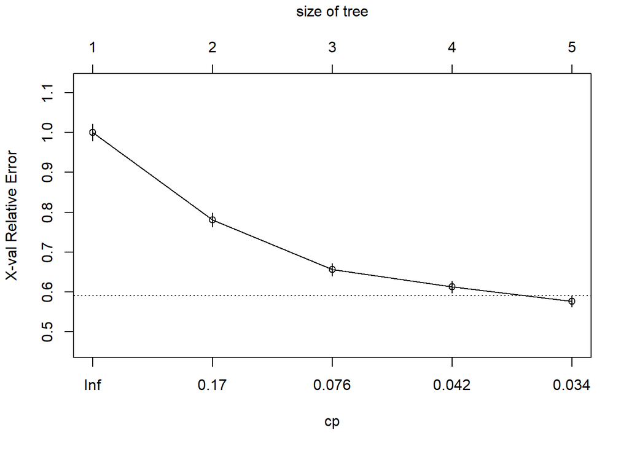

```r
plotcp(rpart.simple)
```

This table shows the relative errors (rel errors) and cp values associated with different splits, as well as the cv rel error values and their standard deviations. On the graph, a horizontal line is drawn 1 standard error above the minimum of the curve, which can assist in choosing the 1SE cp value (providing the minimum value appears on the graph). However, our example tree was estimated with a relatively high cp value to ensure a simple tree, and so we see that the cp function is still decreasing at the lowest observable value of cp.